**Introduction to Python**

|  | Collected by Prof. Seungchul Lee Industrial AI Lab http://isystems.unist.ac.kr/ POSTECH |
| --- | --- |
|  | Reference [Wikidocs](https://wikidocs.net/6) [TensorFlow Essential](https://livebook.manning.com/#!/book/machine-learning-with-tensorflow/chapter-2/1) |

Table of Contents

# 1. What is Python ?

```python
if 4 in [1,2,3,4]: print("4 is in here!")
```

```
4 is in here!
```

위 코드는 다음과 같다.  
"만약 4가 [1,2,3,4] 안에 있으면 '4 is in here!'를 출력한다."

이처럼 Python을 사용하면 직관적으로 프로그래밍을 할 수 있다.

## 1.1 Jupyter notebook

- Esc 키를 누른 후 h 키를 누르면 누르면 jupyter notebook의 cheat sheet가 나온다.
- jupyter notebook에는 Command Mode, Edit Mode, 총 두 가지 모드가 있다. 셀을 클릭하면 셀 내에 코드를 짤수 있는 Edit Mode가 되고, 그 상태에서 ESC를 누르면 셀 자체를 수정할수 있는 Command Mode가 된다.
- 많이 사용하는 단축키
  - Esc: Command Mode로 전환
  - Command Mode
    - a: 현재 셀 위에 셀 추가
    - b: 현재 셀 밑에 설 추가
    - x: 현재 셀 삭제
    - Enter : 현재 셀에서 Edit Mode로 전환
  - Edit Mode
    - Tab: 들여쓰기
    - Shift + Tab: 커서가 위치한 라인, 혹은 드래그된 라인 들여쓰기 취소
    - Esc: Command Mode로 전환
  - 혼용
    - Ctrl + Enter: 현재 셀 실행
    - Shift + Enter: 현재 셀 실행 후 밑의 셀로 이동, 밑에 셀이 없을 경우 셀 추가

# 2. Basic Python

## 2.1 사칙연산

- 계산기를 사용하듯 작성한다.

```python
1 + 2
```

```
3
```

```python
3 / 2.4
```

```
1.25
```

```python
3 * 9
```

```
27
```

## 2.2 변수에 숫자 대입하고 계산하기

```python
a = 1
b = 2
a + b
```

```
3
```

## 2.3 변수에 문자 대입하고 출력하기

```python
a = 'Python'
print(a)
```

```
Python
```

# 3. Data types

- int
- float
- bool
- string
- list
- dictionary (TensorFlow 에서 많이 사용)

Python에는 여러 가지 자료형이 있지만, 특정 자료형을 맞추기 위해 변수 설정을 따로 신경쓸 필요는 없다.

## 3.1 int

- `int` 는 정수형(integer)의 줄임말로, 정수를 저장하는 자료형이다.

```python
a = 123
a = -56
a = 0
type(a)
```

```
int
```

## 3.2 float

- `float` 는 실수형 (Floating-point) 을 표현하며 소수점이 포함된 숫자를 말한다.

```python
a = 1.2
a = -3.45
type(a)
```

```
float
```

## 3.3 bool

- `bool` 은 참, 거짓 (boolean) 두가지 값을 표현한다.

```python
a = True
a = False
type(a)
```

```
bool
```

## 3.4 string

- `string` 은 문자열을 나타내며 단어, 문자 등으로 구성된 문자들의 집합을 의미한다. 예시는 다음과 같다.

```python
a = 'Hello World!'
a = 'a'
a = '123'
type(a)
```

```
str
```

문자열을 사용하기 위해서는 문자열로 만들고 싶은 부분 양 끝을 따옴표(`'`, `"`)로 둘러싸면 된다.

1) 큰따옴표

```python
"Hello World!"
```

```
'Hello World!'
```

2) 작은따옴표

```python
'Python is fun!'
```

```
'Python is fun!'
```

`string` 과 함께 변수를 출력하고 싶을때는 `.format()`을 사용하면 편리하다.  
사용 방법은 다음과 같다.

```
'사용하고 싶은 문자열 { }'.foramt(변수)
```

문자열 내에 중괄호 (`{}`)를 포함시키고 문자열 맨 끝에 `.format(변수)`를 입력하면  
문자열 내에 있는 중괄호 안에 변수가 대입된다.

```python
a = 24
b = 'My age: {}'.format(a)
print(b)
```

```
My age: 24
```

## 3.5 list

```python
odd = [1, 3, 5, 7, 9]
```

리스트를 만들 때는 요소들을 대괄호(`[]`)로 감싸 주고 각 요소들을 쉼표(,)로 구분해준다.

```
리스트명 = [요소1, 요소2, 요소3, ...]
```

리스트 안에는 어떠한 자료형도 포함시킬 수 있다.

```python
a = []
b = [1, 2, 3]
c = ['I', 'love', 'deep', 'learning']
d = [1, 2, 'Combination', 'of', 'int and str']

print(d)
```

```
[1, 2, 'Combination', 'of', 'int and str']
```

`리스트명[숫자]` 를 사용하여 각 요소에 접근 가능하다.  
주의할 점은 **순서가 0번부터 시작한다는 점이다.**

```python
d[0]
```

```
1
```

```python
d[1]
```

```
2
```

```python
d[4]
```

```
'int and str'
```

리스트의 요소를 여러개 갖고 오고 싶은 경우엔 슬라이싱 (slicing) 이란 방법을 사용하면 된다.

```
리스트명[시작:끝]
```

주의할 점은 **마지막 순서는 포함되지 않는다는 점이다.**

```python
d[0:1]
```

```
[1]
```

```python
d[0:2]
```

```
[1, 2]
```

```python
d[1:4]
```

```
[2, 'Combination', 'of']
```

```python
d[0:0]
```

```
[]
```

## 3.6 dictionary

- '이름'='홍길동'이고 '생일'='1970년 1월 1일'인 사람에 대한 변수를 만든다고 생각해 보자.  
  파이썬에는 이런 대응관계를 나타내는 자료형이 있고 이를 `dictionary` 라 부른다.
- `dinctionary` 는 `list` 처럼 순차적으로 해당 요소값을 구하지 않고 `Key` 를 통해 `Value` 를 얻는다. 이것이 `dictionary` 의 큰 특징이다.  
  baseball이란 단어 뜻을 찾기 위해 사전의 내용을 순차적으로 모두 검색하는것이 아니라 baseball이라는 단어가 있는 곳만 펼처 보는 것이다.
- 맨 위의 예시에선 **'이름'이 Key가 되고 '홍길동'이 Value가 될것이다.**

다음은 기본적인 `dictionary` 의 모습이다.

```
{key1 : value1, key2 : value2, key3 : value3}
```

각 요소는 `Key : Value` 형태로 이루어져 있고 쉼표(,)로 구분되어 있다.  
`Key` 에는 변하지 않은 값을 사용하고, `Value` 에는 변하는값, 변하지 않는 값 모두 사용 가능하다.

```python
dic = {
    'name' : 'iSystems',
    'website' : 'http://isystems.unist.ac.kr/teaching/machine-learning/',
    1 : 'Hello World',
    32 : [1,2,3,4]
}
```

`dictionary` 에서 `Key` 를 사용해 `Value` 를 얻는 방법은 다음과 같다.

```
딕셔너리명[키]
```

```python
dic['name']
```

```
'iSystems'
```

```python
dic['website']
```

```
'http://isystems.unist.ac.kr/teaching/machine-learning/'
```

```python
dic[1]
```

```
'Hello World'
```

```python
dic[32]
```

```
[1, 2, 3, 4]
```

# 4. Condition

조건문은 프로그램에서 주어진 조건을 판단하여 상황에 맞게 처리해야 할 때 쓰이는 것이다. Python에서는 조건문에 `if`와 `else`를 사용한다.

`if` 문의 기본 구조는 다음과 같다.

```
if 조건:
    수행할 문장 1
    수행할 문장 2
else:
    수행할 문장 A
    수행할 문장 B
    ...
```

조건문이 참(`True`)이면 `if`문 바로 다음의 문장들 (if 블록)을 수행하고, 거짓이면 `else` 문 다음 문장들 (else 블록)을 수행하게 된다.  
이 때 `else`는 `if` 없이 독립적으로 사용할 수 없다.

```python
weekday = True
if weekday:
    print("Go to the LAB")
else:
    print("Wake up at 11:00 a.m and Go to the LAB")
```

```
Go to the LAB
```

```python
weekday = False
if weekday:
    print("Go to the LAB")
else:
    print("Wake up at 11:00 a.m and Go to the LAB")
```

```
Wake up at 11:00 a.m and Go to the LAB
```

- **주의할 점**

  `if` 문을 만들 때는 `if` 조건: 바로 아래 문장부터 `if`문에 속하는 모든 문장에 **들여쓰기**를 해 주어야 한다.  
  그렇지 않으면 오류가 발생한다.

```python
if True:
    print('Hello')
print('World')
    print('!!!')
```

```
  File "<ipython-input-30-1bea1ba66701>", line 4
    print('!!!')
    ^
IndentationError: unexpected indent
```

# 5. Loop

- 반복적으로 수행해야 할 일이 있을 경우 반복문을 사용한다.
- Python에서는 여러 반복문을 제공해 주는데, 그 중 `for`문을 자주 사용한다.

`for`문의 기본적인 구조는 다음과 같다.

```
for 변수 in 리스트 (또는 튜플, 문자열):
    수행할 문장 1
    수행할 문장 2
    ...
```

리스트나 튜플, 문자열의 첫 번째 요소부터 마지막 요소까지 차례로 변수에 대입되어 `for`문 블록 안의 문장들이 수행된다.

```python
test_list = ['one', 'two', 'three']
for i in test_list:
    print(i)
```

```
one
two
three
```

일정 횟수만큼 반복하는 코드를 짜고 싶은 경우 내장 함수인 `range()`를 이용하면 된다.

```python
for i in range(3):
    print(i)
    print("Hi")
```

```
0
Hi
1
Hi
2
Hi
```

# 6. Function

- 프로그래밍을 하면서 같은 내용을 반복해서 작성한다면, 함수를 사용하는 것이 좋다.
- **'반복적으로 사용되는 가치 있는 부분'**을 한 덩어리로 묶어서 **'어떤 입력값이 주어졌을 때 어떤 결과 값을 돌려주는'** 것을 함수라 한다.

Python 함수의 구조는 다음과 같다.

```
def 함수명(입력 인수):
    수행할 문장 1
    수행할 문장 2
    ...
```

`def` 는 함수를 만들 때 사용하는 키워드이며 함수명은 함수를 만드는 사람이 임의로 정할 수 있다.  
다음과 같이 $x$와 $y$를 입력 인수로 받아 더한 값을 돌려주는 함수를 만든다면,

$f(x,y) = x+y$

```python
def my_sum(x, y):
    return x + y
```

위와 같이 코드를 작성할 수 있다. 여기에서, `return`은 함수의 결과값을 돌려주는 명령어이다. `return`이 없으면 함수는 아무 값도 반환하지 않는다.

```python
a = 3
b = 11
result = my_sum(a, b)
print(result)
```

```
14
```

함수의 인수에 초기값을 미리 설정할 수도 있다.

```python
def my_sum2(x=1, y=2):
    return x + y
```

```python
print(my_sum2(4, 5)) # x == 4, y == 5
print(my_sum2(x=4, y=5)) # x == 4, y == 5
print(my_sum2(x=4)) # x == 4, y == 2
print(my_sum2()) # x == 1, y == 2
```

```
9
9
6
3
```

# 7. Packages

- 모듈, 또는 패키지란 함수나 변수 또는 클래스들을 모아 놓은 파일을 말한다. 즉, 다른 Python 프로그램에서 불러와 사용할 수 있게끔 만들어진 Python 파일이라고도 할 수 있다.
- Python에는 굉장히 유용한 여러 패키지가 있는데 그중 많이 쓰이는 `numpy`, `matplotlib`, 그리고 `tensorflow`에 대해 간략히 소개하겠다.

모듈을 코드 내에 추가하는 방법은 다음과 같다.

```
import 모듈명
import 모듈명 as 임의의 축약 이름
from 모듈명 import 모듈 내 변수, 함수 혹은 클래스
```

각각 의미하는 바는,  
1) 모듈을 전부 코드 내에 추가한다.  
2) 모듈을 전부 코드 내에 추가하고 모듈명을 임의의 축약 이름으로 바꿔 사용한다.  
3) 모듈 내에 있는 **특정 변수, 함수 혹은 클래스만** 추가한다.

## 7.1 numpy

- `numpy`는 거의 모든 Python 프로그램에서 사용되는 패키지이다.
- `array`라는 데이터 타입을 이용해서 matrix나 tensor를 표현하기도 하고, 수학적 계산에서 기초가 되는 여러 함수를 제공한다.

```python
import numpy
a = numpy.array([1, 2, 3])
print(a)
```

```
[1 2 3]
```

```python
import numpy as np
a = np.array([1, 2, 3])
print(type(a))
print(a.shape)
print(a)
```

```
<class 'numpy.ndarray'>
(3,)
[1 2 3]
```

```python
b = np.array([[1,2,3],[4,5,6]])
print(type(b))
print(b.shape)
print(b)
```

```
<class 'numpy.ndarray'>
(2, 3)
[[1 2 3]
 [4 5 6]]
```

[figure not shown]

`np.array`의 각 요소에 접근하는 방법은 `list`에서 사용하던 방법과 같다.  
`어레이명[숫자]`를 사용하여 각 요소에 접근 가능하다.  
차원이 늘어나면 `어레이명[숫자, 숫자, 숫자, ...]` 혹은 `어레이명[숫자][숫자]`로 접근한다.  
**순서가 0번부터 시작한다는 점에 주의한다.**

```python
a[0]
```

```
1
```

```python
a[2]
```

```
3
```

```python
b[0]
```

```
array([1, 2, 3])
```

```python
b[0,1]
```

```
2
```

```python
b[0][1]
```

```
2
```

어레이의 요소를 여러개 갖고 오고 싶은 경우엔 리스트와 같이 슬라이싱 (slicing) 이란 방법을 사용하면 된다.  
`어레이명[시작:끝]`  
차원이 늘어나면 다음과 같이 슬라이싱이 가능하다.

```
어레이명[시작:끝, 시작:끝]
```

**마지막 인덱스는 포함되지 않는다.**

```python
a[0:1]
```

```
array([1])
```

```python
a[0:2]
```

```
array([1, 2])
```

```python
a[0:0]
```

```
array([], dtype=int64)
```

```python
b[0:2]
```

```
array([[1, 2, 3],
       [4, 5, 6]])
```

```python
b[0:2, 0:2]
```

```
array([[1, 2],
       [4, 5]])
```

시작, 끝을 정하지 않고 ':' 만 사용할 시, 해당 dimension의 모든 요소가 포함된다.

```
어레이명[ : ]
```

```python
b[0:2, :]
```

```
array([[1, 2, 3],
       [4, 5, 6]])
```

**`어레이명[시작:끝][시작:끝]`은 기대하는 값을 반환하지 않는다.**

```python
b[0:2][0:2]
```

```
array([[1, 2, 3],
       [4, 5, 6]])
```

참고 링크

- [numpy official tutorial](https://docs.scipy.org/doc/numpy-dev/user/quickstart.html)
- [numpy reference](https://docs.scipy.org/doc/numpy/reference/)

## 7.2 matplotlib

`matplotlib`는 이미지나 데이터를 시각화하거나 그래프를 그릴 때 유용한 패키지이다.

`import` 할 땐 다음과 같이 쓴다.

```python
import matplotlib.pyplot as plt
```

그리고 싶은 이미지나 데이터를 `figure` 위에 올리고 이를 show한다.  
간단한 사용 방법은 다음과 같다.

```
plt.plot(x, y)
plt.show()
```

이미지를 출력할 때는 다음과 같이 작성한다.

```
plt.imshow(이미지)
plt.show()
```

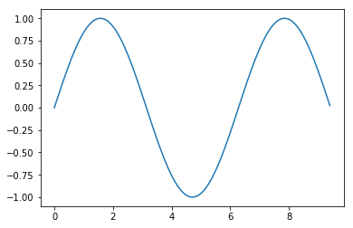

```python
# Compute the x and y coordinates for points on a sine curve
x = np.arange(0,3*np.pi,0.1)
y = np.sin(x)

# Plot the points using matplotlib
plt.plot(x, y)
plt.show()
```

아래에서 사용된 `cPickle`은 Python 자료형으로 데이터를 저장하고 불러오는 패키지이다.

```python
from six.moves import cPickle
input_image = cPickle.load(open('./image_files/lena.pkl', 'rb'))
```

```python
type(input_image)
```

```
numpy.ndarray
```

```python
input_image.shape
```

```
(512, 512)
```

[figure not shown]

```python
plt.imshow(input_image, 'gray')
plt.show()
```

`pyplot`에는 여러 기능들이 있으므로, 잘 사용하면 간결하게 시각화가 가능하다.

참고 링크

- [pyplot official tutorial](https://matplotlib.org/users/pyplot_tutorial.html)
- [pyplot reference](https://matplotlib.org/api/pyplot_summary.html)

## 7.3 TensorFlow

- `TensorFlow`는 google에서 제공하는 deep learning 패키지이다.
- Python 코드는 한 줄씩 실행되어 가며 진행된다면 `TensorFlow`는 모든 계산을 그래프로 그린 뒤, 마지막에 `Session`을 열어 한꺼번에 계산한다는 것이 특징이다.

`TensorFlow`에는 크게 세 가지 구조가 있다.

- 상수를 뜻하는 `tf.constant(임의의 데이터)`
- 변수를 뜻하는 `tf.Variable(임의의 데이터 혹은 random value)`
- 처음엔 아무것도 없는 빈 그릇이지만 들어오는 데이터를 담을 수 있는 `tf.placeholder(데이터 타입, 데이터 모양)`

```python
import tensorflow as tf

a = tf.constant([1, 2, 3])
b = tf.constant([4, 5, 6])

c = tf.constant([[1, 2],[3, 4]])
d = tf.constant([[1,-1], [-1, 1]])

w = tf.Variable([1, 1])

x = tf.placeholder(tf.float32, [2, 2])

summation = a + b
multiplication = c * d
```

```python
summation
```

```
<tf.Tensor 'add:0' shape=(3,) dtype=int32>
```

```python
multiplication
```

```
<tf.Tensor 'mul:0' shape=(2, 2) dtype=int32>
```

위와 같이 결과값이 아직 없다.  
계산기에 비유하자면 `3 + 4`를 적어 놓기만 한 상태로 아직 계산기에 입력하기 전 단계인 것이다.

이 값을 계산하기 위해서는 `tf.Session()` 안에 수식을 집어넣어 주면 된다.

[figure not shown]

```python
sess = tf.Session()
sess.run(summation)
```

```
array([5, 7, 9], dtype=int32)
```

```python
sess.run(multiplication)
```

```
array([[ 1, -2],
       [-3,  4]], dtype=int32)
```

`tf.Variable` 을 사용하기 위해서는 변수를 먼저 초기화해 주는 작업이 필요하다.

```python
init = tf.global_variables_initializer()
sess.run(init)
```

```python
sess.run(w)
```

```
array([1, 1], dtype=int32)
```

`tf.placeholder` 를 사용하기 위해서는 `sess.run()`을 할 때 `feed_dict`라는 인수를 이용하여 데이터를 넣어주면 된다.  
`feed_dict`에 `dictionary` 형태로 값을 넣는다.  
이 때 `Key` 는 `placeholder`의 변수명이 되고 `Value`는 넣고 싶은 데이터가 된다.

```python
sess.run(x, feed_dict={x : [[1,2],[3,4]]})
```

```
array([[ 1.,  2.],
       [ 3.,  4.]], dtype=float32)
```

```python
%%javascript
$.getScript('https://kmahelona.github.io/ipython_notebook_goodies/ipython_notebook_toc.js')
```